# Rooftop Solar Potential Map ☀

## Sarah Underwood

1. The problem
2. The solution
3. The vision

# 1. Uh-oh, we have a big problem...

## Climate change 😭😭

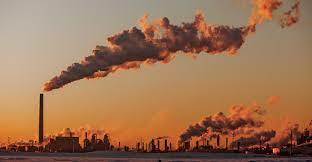

## Energy is the biggest culprit 😭

[figure not shown]

# 2. Solar power to the rescue 🌞

## Not every roof is fit for solar!!

- Local weather
- Roof size
- Roof condition
- Roof material

# 3. The vision

Okayyy so how do we easily identify which roofs are good for solar?!

## Part I: Recognizing Rooftops

**The data**

国土地理院が提供しているオープンデータ ♡

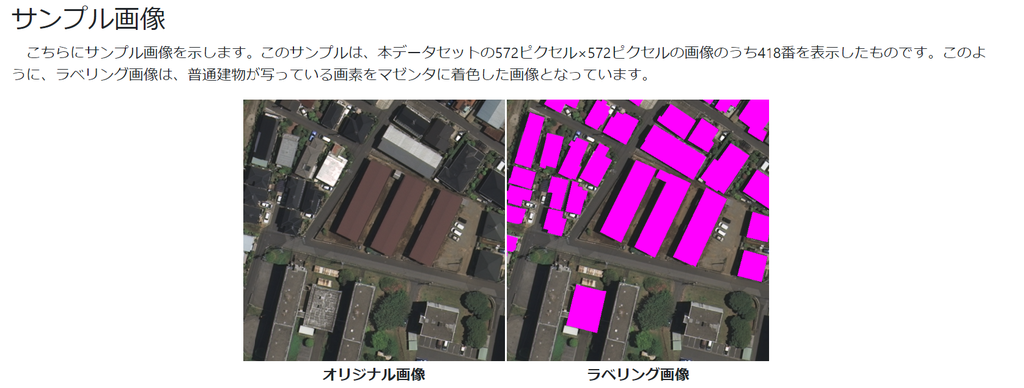

### CNN model

With the labeled dataset, train a model to recognize rooftops!!

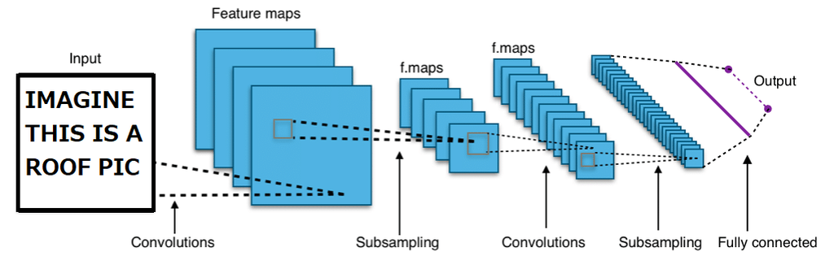

## Part II: Rooftop Analysis

Okay so we can recognize roofs!! Next we gotta see:

- What is size?
- Is the roof flat or slanted?
- What is the material?
- Is there something on the roof?

### Size

CNN output-- use these images to calculate size

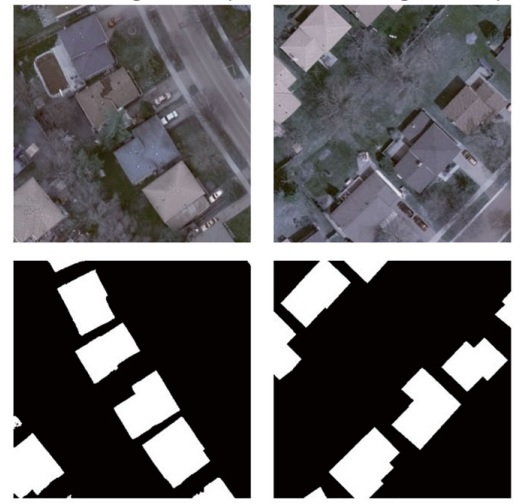

How big does a roof need to be?

- The average household needs a 5kW system
- A 5kW system requires about $30m^2$

Simple math to calculate ฅ^•ω•^ฅ

### Material

Probably through color analysis

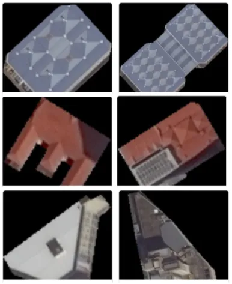

### Slope

Image segmentation to carve out the geometric shapes of a rooftop to determine if flat or sloped

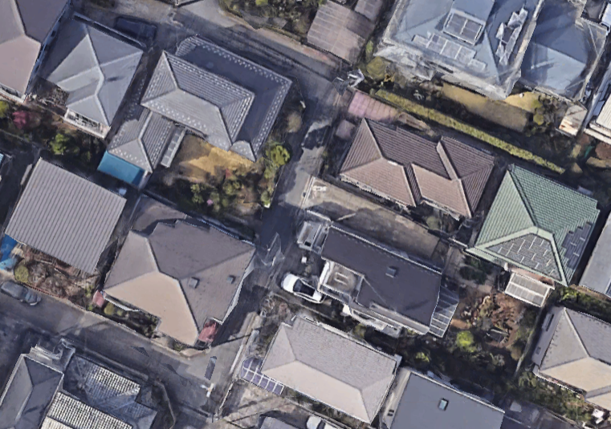

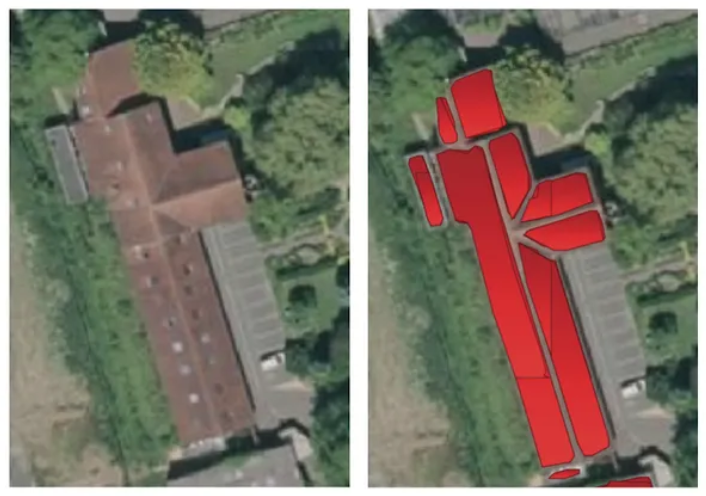

### Obstructions

Color differences to detect obstructions

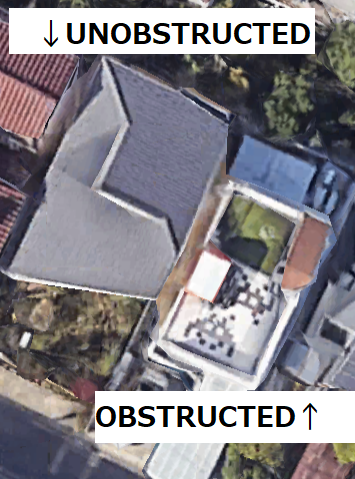

## Part IV: Estimated generation

For our houses that are good for solar, we'll calculate a yearly generation potential!!

```
                          Yay this how is good for solar!!             This house isn't :(
```

[figure not shown]

```python
import pandas as pd

weather = pd.read_csv('data.csv', encoding="cp932")
weather.head()
```

|  |  |  | ダウンロードした時刻：2024/01/20 11:28:48 |
| --- | --- | --- | --- |
| NaN | 府中 | 府中 | 府中 |
| 年月日時 | 日照時間(時間) | 日照時間(時間) | 日照時間(時間) |
| NaN | NaN | 品質情報 | 均質番号 |
| 2023/1/1 1:00:00 | NaN | 8 | 1 |
| 2023/1/1 2:00:00 | NaN | 8 | 1 |

```python
weather[8:21][:]
```

|  |  |  | ダウンロードした時刻：2024/01/20 11:28:48 |
| --- | --- | --- | --- |
| 2023/1/1 6:00:00 | NaN | 8 | 1 |
| 2023/1/1 7:00:00 | 0.0 | 8 | 1 |
| 2023/1/1 8:00:00 | 0.8 | 8 | 1 |
| 2023/1/1 9:00:00 | 1.0 | 8 | 1 |
| 2023/1/1 10:00:00 | 1.0 | 8 | 1 |
| 2023/1/1 11:00:00 | 1.0 | 8 | 1 |
| 2023/1/1 12:00:00 | 1.0 | 8 | 1 |
| 2023/1/1 13:00:00 | 1.0 | 8 | 1 |
| 2023/1/1 14:00:00 | 1.0 | 8 | 1 |
| 2023/1/1 15:00:00 | 1.0 | 8 | 1 |
| 2023/1/1 16:00:00 | 1.0 | 8 | 1 |
| 2023/1/1 17:00:00 | 0.3 | 8 | 1 |
| 2023/1/1 18:00:00 | NaN | 8 | 1 |

Solar generation system wattage x sunlight hours = estimated generation

## The End!!!

[figure not shown]